# Random forest classifier in identifying breast cancer

> Identifying tumors via clinical traits is a hard work and it needs expertise of morphology and physiology. In this tutorial, we will work on building a random forest classifier model and use our model in breast cancer identification based on clinical traits we have trained.

> Data description Attribute Information: 1. Sample code number: id number 2. Clump Thickness: 1 - 10 3. Uniformity of Cell Size: 1 - 10 4. Uniformity of Cell Shape: 1 - 10 5. Marginal Adhesion: 1 - 10 6. Single Epithelial Cell Size: 1 - 10 7. Bare Nuclei: 1 - 10 8. Bland Chromatin: 1 - 10 9. Normal Nucleoli: 1 - 10 10. Mitoses: 1 - 10 11. Class: (2 for benign, 4 for malignant)

```r
##read data
##data resource: http://archive.ics.uci.edu/ml/machine-learning-databases/breast-cancer-wisconsin/breast-cancer-wisconsin.data
breast = read.csv("Downloads/breast-cancer-wisconsin.data",header = F)
```

> Attributes from 2 to 10 were already scaled from 1 to 10. Therefore, we don’t do any preprocessing. Attribute 11 will be the label in our classfiication problem.

```r
##Next, we random split 20% samples out as test data and leave the rest 80% as training dataset.
library(dplyr)
##the whole dataset contains 458 benign samples and 241 malignant samples
table(breast$V11)
```

```
##
##   2   4
## 458 241
```

```r
test = sample_frac(breast,0.2)
train = breast[!breast$V1%in%test$V1,]

##Sometimes class of variables in R is very annoying!
for (i in c(1:ncol(test))) {
  test[,i]=as.numeric(test[,i])
}
test_x = test[,2:10]
test_y = test[,11]
for (i in c(1:ncol(train))) {
  train[,i]=as.numeric(train[,i])
}
train_x = train[,2:10]
train_y = train[,11]
```

```r
##We start by building a simple random forest classifier
library(randomForest)
set.seed(111)
simple_rf <- randomForest(train_x,y=as.factor(train_y), importance = TRUE)
simple_rf
```

```
##
## Call:
##  randomForest(x = train_x, y = as.factor(train_y), importance = TRUE)
##                Type of random forest: classification
##                      Number of trees: 500
## No. of variables tried at each split: 3
##
##         OOB estimate of  error rate: 2.96%
## Confusion matrix:
##     2   4 class.error
## 2 344   9  0.02549575
## 4   7 181  0.03723404
```

```r
##Then we can use test data to examine how good this classifier model is
pred_y <- predict(simple_rf, test_x, type = "class")
table(pred_y,as.factor(test_y))
```

```
##
## pred_y  2  4
##      2 85  3
##      4  5 47
```

> Comparing the predicted class with real label, we can conclude this random forest classifier have high accuracy of prediction. However, considering the unequal sample size of the benign and the malignant, we need to have a good way to quantify the model

```r
library(ROCR)
```

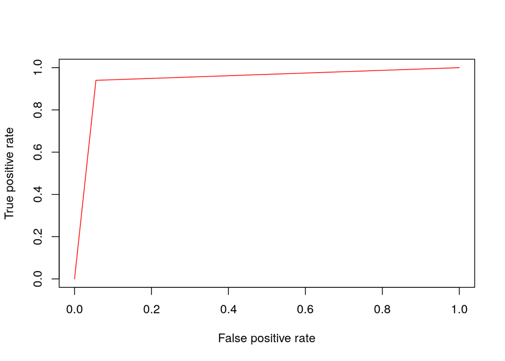

```r
pred_y=as.numeric(as.character(pred_y))
pred <- prediction(pred_y,test_y)
rocs <- performance(pred, "tpr", "fpr")
plot(rocs, col=rainbow(10))
```

> So far we can be very confident that our model is a very good classifier. High accuracy and good balance balance between false positive rate and false negative rate. But since two types of samples are not the same sample size, it is interesting to test classifier performance by unbalanced training set. Furthermore, by adding noise to train set or test set, we also evaluate how the classifier works.

```r
set.seed(111)
benign = breast[breast$V11==2,]
malignant = breast[breast$V11==4,]
benign_train = sample_frac(benign,0.75)
benign_test = benign[!benign$V1%in%benign_train$V1,]
malignant_train = sample_frac(malignant,0.25)
malignant_test = malignant[!malignant$V1%in%malignant_train$V1,]
test = rbind(benign_test,malignant_test)
train = rbind(benign_train,malignant_train)

for (i in c(1:ncol(test))) {
  test[,i]=as.numeric(test[,i])
}
test_x = test[,2:10]
test_y = test[,11]
for (i in c(1:ncol(train))) {
  train[,i]=as.numeric(train[,i])
}
train_x = train[,2:10]
train_y = train[,11]
table(test_y)
```

```
## test_y
##   2   4
##  95 179
```

```r
table(train_y)
```

```
## train_y
##   2   4
## 344  60
```